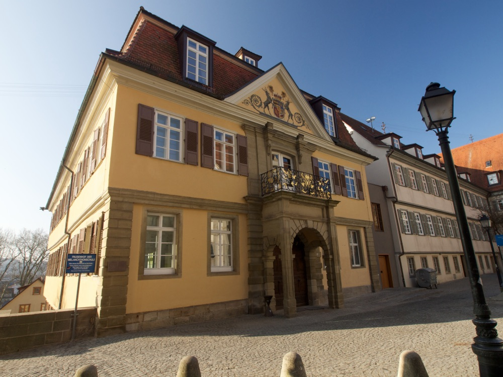

## Bildungswissenschaften? It’s a mess!

Sitzung 1: Einführung in das Studium der Bildungswissenschaften

Prof. Dr. Samuel Merk

Wintersemester 2026/27

Wirtschafts- und Sozialwissenschaftliche Fakultät · Institut für Erziehungswissenschaft

# Herzlich Willkommen!

## Heute

- Mit wem haben Sie es zu tun?
- Welchen Gestaltungsvorschlag haben wir für die Vorlesung?
- Bildungswissenschaften? It’s a mess!
  - Strukturierungsvorschläge:
    - Topologie beteiligter Disziplinen
    - Erkenntnisinteressen

## Mit wem haben Sie es zu tun?

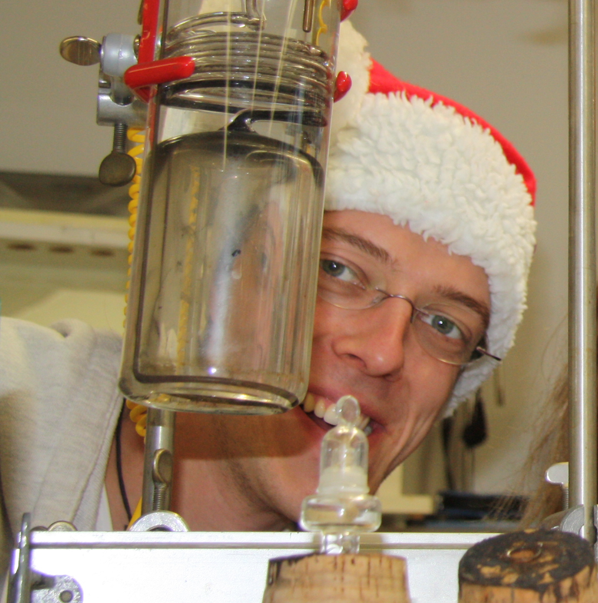

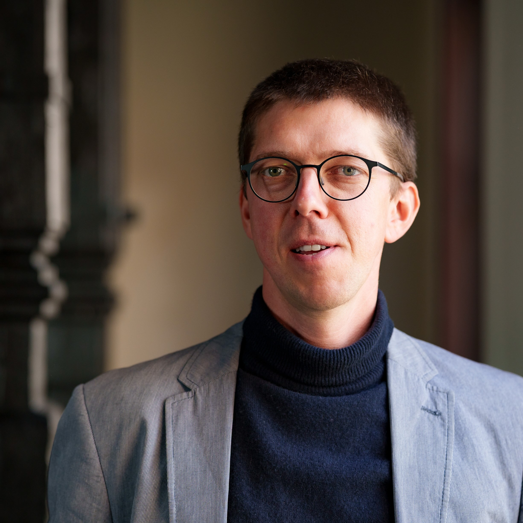

Zweites Staatsexamen Mathematik, Chemie, Erziehungswissenschaft

StR an der GSS Tübingen & wiss. Mitarbeiter UT

TT-Prof. für empirische Schul- und Unterrichtsforschung an der PHKA

Lehrstuhl Professionsforschung UT

## Gestaltungsvorschlag für die Vorlesung

- Modulhandbuch bindet uns an gewisse Inhalte, Lernziele und Prüfungsformen
- Modulhandbuch bindet uns auch an eine Prüfungsform:
  - 60 Minuten schriftliche Klausur (Multiple Choice, Kurzantworten, offene Fragen)
  - 03.02.2027 14:15, E-Prüfung auf Chromebooks des E-Prüfungszentrums
  - Zweittermin Anfang April 2027

## Gestaltungsvorschlag für die Vorlesung

- Mein Ziel: Nach der Vorlesung
  - verfügen Sie über ein **Vokabular**, das Ihnen erlaubt gewisse **Perspektiven** von Bildungswissenschaftler:innen **nachzuvollziehen** und diese kompetent zu **kritisieren**
  - können Sie **informiert entscheiden können** ob Sie sich für Bildungswissenschaften interessieren
- Wie VL *gemeinsam* gestalten?
  - Vorschlag: Mindestens zwei Sitzungen zu **Themen Ihrer Wahl**
  - Vorschlag: Jede Woche (fakultative) Aufgaben während und nach der VL. Anschließend kurze Diskussion deren (Biggs, 1996)
  - Weitere Vorschläge von Ihnen?

# Bildungswissenschaften? It’s a mess!

## Bildungswissenschaften

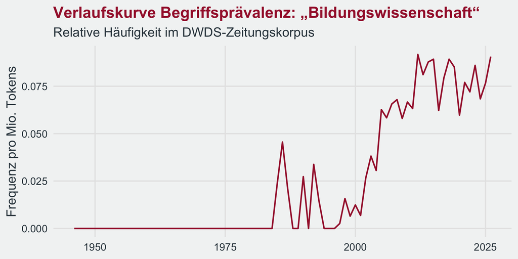

Abbildung 1: Verlaufskurve „Bildungswissenschaften“ im DWDS-Zeitungskorpus (Digitales Wörterbuch der deutschen Sprache, 2026)

## Bildungswissenschaften

  > *»diejenigen wissenschaftlichen Disziplinen und Teildisziplinen, die sich wissenschaftlich in jeder denkbaren theoretischen und methodischen Hinsicht [. . . ] auf Themen, Institutionen, Prozesse, Resultate von Bildung und Ausbildung beziehen«* (Terhart, 2012, S. 28)

## Beispiele Bildungswissenschaftlicher Studien

- Erziehungswissenschaft: Hübner et al. (2026)
- Soziologie: Neugebauer et al. (2025)
- Psychologie: Basarkod et al. (2023)

## Glossar

## Literatur

Basarkod, G., Marsh, Guo, Dicke, Xu, & and Parker, P. D. (2023). The Big-Fish-Little-Pond Effect for Reading Self-Beliefs: A Cross-National Exploration with PISA 2018. *Scientific Studies of Reading*, *27*(4), 375–392. https://doi.org/10.1080/10888438.2023.2174028

Biggs, J. (1996). Enhancing Teaching through Constructive Alignment. *Higher Education*, *32*(3), 347–364. https://doi.org/10.1007/BF00138871

Cramer, C. (2019). Fachdidaktiken Und Bildungswissenschaften. Verhältnisbestimmungen Und Deren Implikationen Für Professionalisierung Und Lehrerbildung Aus Bildungswissenschaftlicher Perspektive. [Online; Gedruckt]. In E. Christophel, M. Hemmer, F. Korneck, T. Leuders, & P. Labudde (Hrsg.), *Fachdidaktische Forschung Zur Lehrerbildung* (S. 275–292). Waxmann.

Digitales Wörterbuch der deutschen Sprache. (2026). *DWDS-Verlaufskurve für „Bildungswissenschaften“*. https://www.dwds.de/r/plot/?view=1&corpus=zeitungenxl&norm=date%2Bclass&smooth=spline&genres=0&grand=1&slice=1&prune=0.05&window=0&wbase=0&logavg=0&logscale=0&xrange=1946%3A2026&q1=Bildungswissenschaften

Döring, N., & Bortz, J. (2016). *Forschungsmethoden und Evaluation in den Sozial- und Humanwissenschaften* (5. Aufl.). Springer.

Hübner, N., Kohler, B., Neumann, M., & Becker, M. (2026). Die Vergessenen: Einblicke in kriteriale Präferenzen und die Gewichtung von mündlichen Schulnoten durch Lehrpersonen. *Zeitschrift für Erziehungswissenschaft*, *29*(3), 763–788. https://doi.org/10.1007/s11618-026-01381-z

Neugebauer, M., Becker, M., Bihler, L.-M., & Wagner, J. (2025). Well-Being Scarring Effects of College Non-Completion. *Social Science Research*, *127*, 103138. https://doi.org/10.1016/j.ssresearch.2024.103138

Terhart, E. (2012),,Bildungswissenschaften“: Verlegenheitslösung, Sammeldisziplin, Kampfbegriff? *Zeitschrift für Pädagogik*, *58*(1), 22–39. https://doi.org/urn:nbn:de:0111-pedocs-104938